# Analyzing the Severe Weather Events: Which are the Deadliest?

## Synopsis

This document contains an analysis of a data set provided by the U.S. National Oceanic and Atmospheric Administration’s (NOAA) storm database. The goal is to identify which types of events are most harmful to the health of populations, and which events deal the most economic damage. First, the data was processed in R by taking the original file and extracting only the relevant data. Next, data was partially cleaned by refactoring some erroneous features and then numbers were scaled according to the NOAA Storm Data Documentation in order to obtain more precise figures. The figures show only the events that are above average in their severity of damage dealt in comparison to all other events.

## Data Processing

This analysis made use of the R Package “tidyverse”.

The raw data was loaded into R using the base read.csv function. Afterwards, only the columns of interest were extracted from the main dataframe and stored in a new data frame for easier analysis. New variables were created by simply summing up other variables together, namely the Total_Injuries and Total_Fatalities variables. Then, yet another variable was created in the same manner called Total_FI, which combined both Total_Injuries and Total_Fatalities into one for each different event. However, with the sheer amount of observations and different types of events, there would be no way to fit so many on a single plot. So, the data was further subsetted by including events that had a higher Total_FI value than the mean Total_FI value across all events. This narrowed down the number of observations to 18, making for a very clear and concise plot.

```r
require(tidyverse)
```

```r
SD = read.csv("repdata_data_StormData.csv")
Pop_Health = SD[,c(8,23,24)]
Pop_Health_Total = Pop_Health %>% group_by(EVTYPE) %>% summarize(Total_Fatalities = sum(FATALITIES),
                                                                 Total_Injuries = sum(INJURIES))

PHT_Subset = subset(Pop_Health_Total, Total_Fatalities > 0 | Total_Injuries > 0)

PHT_Subset = PHT_Subset %>% mutate(Total_FI = Total_Fatalities + Total_Injuries)

PHT_Subset = PHT_Subset %>% arrange(desc(Total_FI))

PHT_Subset = subset(PHT_Subset, Total_FI > mean(Total_FI))

PHT_Subset = PHT_Subset %>% arrange(desc(Total_FI))
```

The PHT_Subset was sufficient to examine which events were deadliest in terms of human deaths and injuries. Another tidy dataset was prepared in order to answer the question of which events caused the most economic damage. Similarly, only variables of interest were subsetted from the main raw dataframe. However, the data collected for variables pertaining to economic damage were far more unclean than the human casualty variables. Raw numeric variables were reported for the variables PROPDMG and CROPDMG, standing for “property damage” and “crop damage”, respectively, but each observation was accompanied by a factor variable describing the amount. For example, the documentation provided by the NOAA outlined factor levels “K”, “M”, and “B” to represent “thousands of dollars”, “millions of dollars”, and “billions of dollars”. So a PROPDMG value of 25 accompanied by a “M” in the PROPDMGEXP column represented a total property damage of 25 million USD. The data recorders also made mistakes while documenting the factor level of PROPDMGEXP, with some observations being mislabeled with lowercase letters instead of the standard uppercase (i.e. “m” instead of “M”, “b” instead of “B”.) This was solved by releveling the mislabeled factors with their appropriate match. Additionally, there were several additional levels with no explanation of their meaning in the documentation, such as levels with numbers 0-8 in the PROPDMGEXP factor. However, since there were only a handful of observations with these levels as their label, they could be safely ignored without too much of an effect on the overall picture. The values were appropriately rescaled using the PROPDMGEXP and CROPDMGEXP levels and as with the human casualty variables, a new dataframe containing only high damaging events was created that contained the total property and crop damage dealt in billions of dollars.

```r
Econ_Damage = SD[,c(8,25,26,27,28)]

Econ_Subset = subset(Econ_Damage, PROPDMG > 0 | CROPDMG > 0)

Econ_Subset$PROPDMGEXP = plyr::revalue(Econ_Subset$PROPDMGEXP, c("h" = "H", "m" = "M"))
Econ_Subset$CROPDMGEXP = plyr::revalue(Econ_Subset$CROPDMGEXP, c("k" = "K", "m" = "M"))

Econ_Subset$PROPDMG[Econ_Subset$PROPDMGEXP == "H"] =
  (Econ_Subset$PROPDMG[Econ_Subset$PROPDMGEXP == "H"])*100
Econ_Subset$PROPDMG[Econ_Subset$PROPDMGEXP == "K"] =
  (Econ_Subset$PROPDMG[Econ_Subset$PROPDMGEXP == "K"])*1000
Econ_Subset$PROPDMG[Econ_Subset$PROPDMGEXP == "M"] =
  (Econ_Subset$PROPDMG[Econ_Subset$PROPDMGEXP == "M"])*1000000
Econ_Subset$PROPDMG[Econ_Subset$PROPDMGEXP == "B"] =
  (Econ_Subset$PROPDMG[Econ_Subset$PROPDMGEXP == "B"])*1000000000

Econ_Subset$CROPDMG[Econ_Subset$CROPDMGEXP == "K"] =
  (Econ_Subset$CROPDMG[Econ_Subset$CROPDMGEXP == "K"])*1000
Econ_Subset$CROPDMG[Econ_Subset$CROPDMGEXP == "M"] =
  (Econ_Subset$CROPDMG[Econ_Subset$CROPDMGEXP == "M"])*1000000
Econ_Subset$CROPDMG[Econ_Subset$CROPDMGEXP == "B"] =
  (Econ_Subset$CROPDMG[Econ_Subset$CROPDMGEXP == "B"])*1000000000

Total_Econ = Econ_Subset %>% group_by(EVTYPE) %>% summarize(TotCropDmg = sum(CROPDMG),
                                                            TotPropDmg = sum(PROPDMG))
Total_Econ = Total_Econ %>% mutate(Total_Damage = TotCropDmg + TotPropDmg)

High_Damage = subset(Total_Econ, Total_Damage > mean(Total_Damage))
High_Damage$Total_Damage = (High_Damage$Total_Damage)/1000000000
```

## Results

Two plots were created which compactly answer the initial questions of which events are most damaging to human health, and which are most damaging to the economy.

The first plot was created using the PHT_Subset dataframe, which outlined the combined number of human injuries and fatalities for each of the 18 deadliest events. Exact numbers are shown above each bar in the plot.

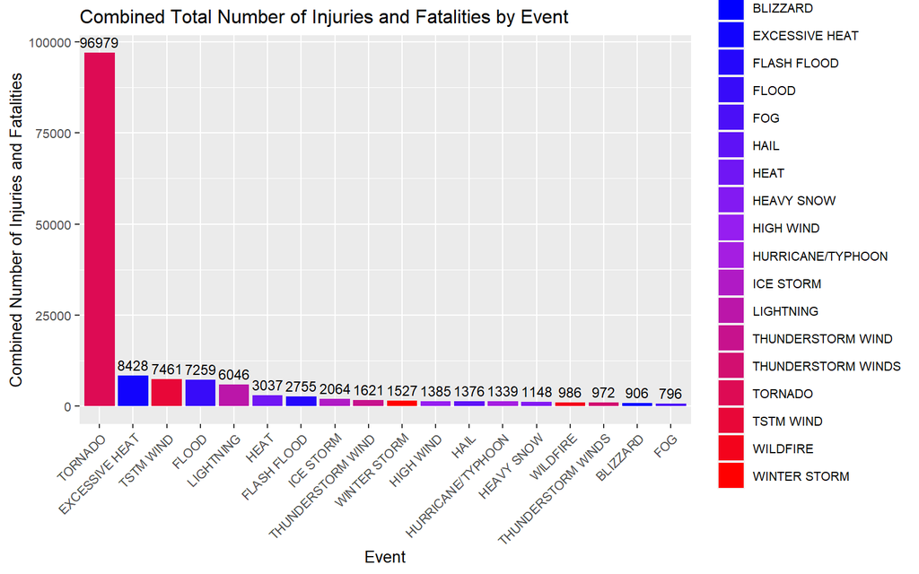

```r
palette = colorRampPalette(c("blue","purple","red"))

g = ggplot(PHT_Subset, aes(x = reorder(EVTYPE, -Total_FI), y = Total_FI, fill = EVTYPE))
g + geom_col() +
    theme(text = element_text(size = 10),
          axis.text.x = element_text(angle = 45, hjust = 1)) +
    xlab("Event") +
    ylab("Combined Number of Injuries and Fatalities") +
    ggtitle("Combined Total Number of Injuries and Fatalities by Event") +
    scale_fill_manual(values = palette(18)) +
    geom_text(aes(label = Total_FI), size = 3, vjust = -0.5)
```

The second plot was created using the High_Damage dataframe, which outlined the total economic damage done (property + crop damage) by the most damaging events. The units are in billions of U.S. dollars, and the rounded values are displayed above each bar.

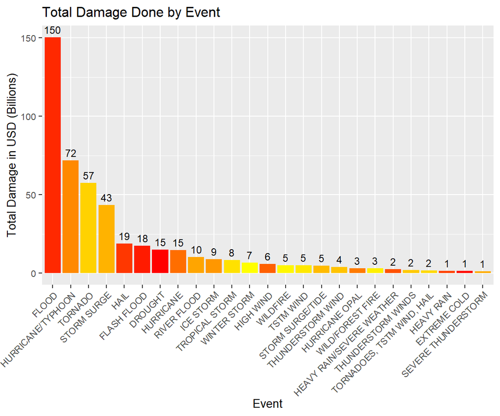

```r
palette2 = colorRampPalette(c("red","orange","yellow"))

g2 = ggplot(High_Damage, aes(x = reorder(EVTYPE, -Total_Damage), y = Total_Damage, fill = EVTYPE))
g2 + geom_col() +
  theme(text = element_text(size = 10),
        axis.text.x = element_text(angle = 45, hjust = 1)) +
  xlab("Event") +
  ylab("Total Damage in USD (Billions)") +
  ggtitle("Total Damage Done by Event") +
  scale_fill_manual(values = palette2(25)) +
  geom_text(aes(label = round(Total_Damage)), size = 3, vjust = -0.5) +
  theme(legend.position = "none")
```